# Likelihood exercises: worked solutions

PCB 6455 / BSC 4933: Biometry | Lecture 15

Dr. Brian Maitner

## How to use this

The code from Lecture 15, filled in, with the numbers it produces.

Optimizers are numerical, so your last decimal place may differ from mine. Anything beyond that is worth asking about.

## Setting up

```r
bbs <- read.csv("https://github.com/bmaitner/biometry_course/raw/refs/heads/main/data/BBS/FL_BBS.csv")

routes_2019 <- length(unique(bbs$Route[bbs$Year == 2019]))

with_bobwhite <- length(unique(bbs$Route[bbs$Year == 2019 &
                       bbs$Scientific_Name == "Colinus virginianus"]))

bobwhite <- bbs$total_sightings[bbs$Scientific_Name == "Colinus virginianus"]

c(routes = routes_2019, with_bobwhite = with_bobwhite, counts = length(bobwhite))
```

```
       routes with_bobwhite        counts
           71            52          1360
```

## Trying values of `p`

```r
dbinom(x = 52, size = 71, prob = 0.5)
```

```
[1] 3.671053e-05
```

```r
dbinom(x = 52, size = 71, prob = 0.6)
```

```
[1] 0.006933064
```

```r
dbinom(x = 52, size = 71, prob = 0.73)
```

```
[1] 0.1063214
```

```r
dbinom(x = 52, size = 71, prob = 0.8)
```

```
[1] 0.04151161
```

The biggest is at `p = 0.73`, and 52/71 = 0.732.

## Why the product fails

```r
prod(dpois(bobwhite[1:5], lambda = 10.8))
```

```
[1] 2.434196e-23
```

```r
prod(dpois(bobwhite[1:50], lambda = 10.8))
```

```
[1] 1.847009e-303
```

```r
prod(dpois(bobwhite, lambda = 10.8))
```

```
[1] 0
```

The last one is not a small number. It is **zero**: R cannot hold anything below about 2.23^{-308}.

```r
sum(dpois(bobwhite, lambda = 10.8, log = TRUE))
```

```
[1] -8455.43
```

On the log scale the same quantity is an ordinary number.

## One parameter, fitted

```r
binom_nll <- function(p){
  -dbinom(x = with_bobwhite, size = routes_2019, prob = p, log = TRUE)
}

fit <- optimize(binom_nll, interval = c(0, 1))

c(estimate = fit$minimum, nll = fit$objective)
```

```
 estimate       nll
0.7323749 2.2402544
```

Compare with the formula answer:

```r
with_bobwhite / routes_2019
```

```
[1] 0.7323944
```

## Two parameters, fitted

```r
nb_nll <- function(mu, size){
  -sum(dnbinom(bobwhite, mu = mu, size = size, log = TRUE))
}

fit_nb <- optim(par = c(mu = 10, size = 1),
                fn = function(p){
                  nb_nll(p["mu"], p["size"])
                },
                method = "BFGS")

round(fit_nb$par, 3)
```

```
    mu   size
10.786  1.368
```

|  | method | mu | size |
| --- | --- | --- | --- |
|  | method of moments | 10.782 | 1.155 |
| mu | maximum likelihood | 10.786 | 1.368 |

The means agree. The clumping does not, and likelihood is the one to trust.

## Do the two routes agree?

```r
library(bbmle)

m1 <- mle2(minuslogl = nb_nll,
           start = list(mu = 10, size = 1),
           data = list(bobwhite = bobwhite))

coef(m1)
```

```
       mu      size
10.785957  1.368266
```

```r
coef(m1) - fit_nb$par
```

```
  mu size
   0    0
```

Zero, because `mle2()` calls `optim()` underneath. A stronger check is to change the search algorithm:

```r
fit_nm <- optim(par = c(mu = 10, size = 1),
                fn = function(p){
                  nb_nll(p["mu"], p["size"])
                },
                method = "Nelder-Mead")

round(fit_nm$par - fit_nb$par, 4)
```

```
    mu   size
 1e-04 -6e-04
```

## Estimating the decline

The two pieces you had to supply were the **body of `trend_nll`** and the **call to it** inside `optim`:

```r
bob <- bbs[bbs$Scientific_Name == "Colinus virginianus", ]
counts <- bob$total_sightings
year <- bob$Year - min(bob$Year)

trend_nll <- function(mu0, decline, size){
  mu <- mu0 * (1 - decline)^year
  -sum(dnbinom(counts, mu = mu, size = size, log = TRUE))
}

fit_trend <- optim(par = c(mu0 = 15, decline = 0.03, size = 1),
                   fn = function(p){
                     trend_nll(p["mu0"], p["decline"], p["size"])
                   },
                   method = "L-BFGS-B",
                   lower = c(0.1, -0.5, 0.05),
                   upper = c(100, 0.5, 50))

round(fit_trend$par, 4)
```

```
    mu0 decline    size
14.7823  0.0291  1.4333
```

## What that answer means

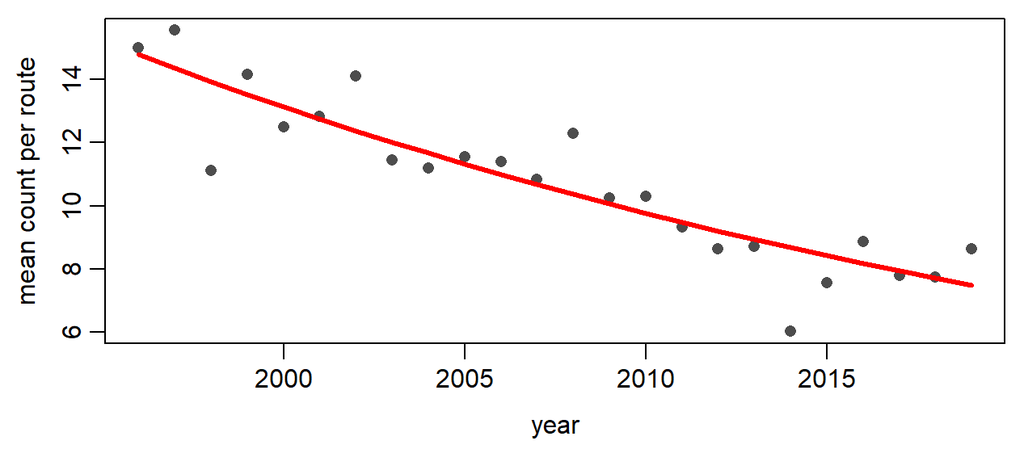

- **`mu0` = 14.8**: expected count per route in 1996
- **`decline` = 0.029**: about **2.9% fewer each year**, against the 3% we assumed on Thursday
- **`size` = 1.43**: the clumping, slightly less clumped than the no-trend fit, because some of the spread was really the decline

## Was the trend worth fitting?

```r
c(no_trend = round(fit_nb$value, 1), with_trend = round(fit_trend$value, 1))
```

```
  no_trend with_trend
    4626.8     4595.6
```

The trend improves the fit by about **31** log-likelihood units, and costs one extra parameter.

Whether 31 is worth one parameter is **next week’s lecture**. The honest answer today is “almost certainly yes, and here is how we will check”.

## Whichever species you picked

Northern Cardinal, as one example:

```r
cards <- bbs$total_sightings[bbs$Scientific_Name == "Cardinalis cardinalis"]

nb_nll2 <- function(mu, size){
  -sum(dnbinom(cards, mu = mu, size = size, log = TRUE))
}

fit_card <- optim(par = c(mu = 50, size = 1),
                  fn = function(p){
                    nb_nll2(p["mu"], p["size"])
                  },
                  method = "BFGS")

round(fit_card$par, 3)
```

```
   mu  size
51.15  2.55
```

```r
round(mean(cards)^2 / (var(cards) - mean(cards)), 3)   # moment estimate of size
```

```
[1] 1.955
```

The two estimates differ, as they did for the bobwhite. **Which one is larger depends on the species:** cardinals give 2.55 against 1.95, but Northern Mockingbird gives 1.18 against 1.34, the other way round. There is no rule to memorize here, only a reason to prefer likelihood.

## What to take away

1. Likelihood is the probability of your data, read as a function of the parameters.
2. Logs turn an impossible product into a workable sum.
3. An optimizer finds the parameters that minimize the negative log-likelihood.
4. **Check it**: against a formula where one exists, against a second algorithm, and against a plot.